[figure not shown]

# Síntesis y Aplicación

Los grafos son aplicables a todo campo donde haya relación entre actores, agentes, nodos, etc. En el campo de la innovación, hay característisticas particulares que pueden ser resumidas así:

### Grupo de Inventores (I): Los Orígenes de la Novedad

Los **Inventores** son el corazón de la innovación. Su importancia radica en su rol como **generadores de conocimiento original y disruptivo**.

- **Fuentes de Conocimiento:** Son quienes crean nuevas ideas, patentes, publicaciones científicas y prototipos. Sin ellos, el flujo de "novedad" simplemente no existiría.
- **Validación Técnica:** El prestigio de un inventor (alto índice Scopus, patentes exitosas, premios) funciona como un **sello de calidad y viabilidad técnica**. Otros actores confían en su experiencia para decidir si una idea merece ser explorada o financiada.
- **Atracción de Colaboración:** Los inventores con alto prestigio atraen a otros investigadores, emprendedores y empresas, buscando colaborar y acceder a su conocimiento de vanguardia. Si un inventor de alto prestigio está aislado o sobrecargado, el flujo de nuevas ideas puede estancarse.

### Grupo de Emprendedores (E): Los Catalizadores de la Comercialización

Los **Emprendedores** son los que transforman las ideas en valor. Son el puente esencial entre el laboratorio o la mente del inventor y el mercado.

- **Agentes de Transformación:** Toman los inventos, les dan forma de producto o servicio, y desarrollan modelos de negocio. Sin ellos, muchas innovaciones se quedarían solo en papel.
- **Atracción de Capital y Talento:** El prestigio de un emprendedor (experiencia previa exitosa, capacidad de liderazgo) es clave para **atraer financiación y talento** para escalar la innovación.
- **Conexión con el Mercado:** Son los principales impulsores del **flujo de la innovación hacia los usuarios y clientes**, detectando necesidades y validando soluciones. Si los emprendedores carecen de prestigio o de conexiones, las innovaciones pueden quedarse "atascadas" en etapas tempranas.

### Grupo de Consultores (C): Los Facilitadores y Conectores Estratégicos

Los **Consultores** son los engranajes que lubrican y conectan la maquinaria de la innovación, proporcionando experticia y red.

- **Asesoramiento Experto:** Ofrecen conocimiento especializado en áreas clave como estrategia, propiedad intelectual, marketing o gestión, crucial para superar obstáculos.
- **Puentes de Conocimiento:** Un consultor con alto prestigio como no solo aporta conocimiento, sino también una **vasta red de contactos**. Pueden conectar inventores con financistas, emprendedores con expertos técnicos, facilitando el **flujo de información y oportunidades** a través de barreras sectoriales o geográficas.
- **Reducción de Incertidumbre:** Su experiencia y reputación ayudan a validar decisiones y reducir la incertidumbre en un proceso inherentemente riesgoso como la innovación. Si estos nodos son escasos o inaccesibles, el flujo puede ralentizarse por falta de dirección o conexiones.

### Grupo de Financistas (F): Los Impulsores de Recursos

Los **Financistas** son el motor económico de la innovación, proveyendo el capital necesario para que las ideas despeguen y crezcan.

- **Aportación de Capital:** Su función principal es inyectar el **flujo de recursos financieros** que permite investigar, desarrollar prototipos, comercializar productos y escalar operaciones.
- **Validación de Oportunidades:** El prestigio de un financista (historial de inversiones exitosas) sirve como una **señal de validación** para el mercado y otros inversores. Su compromiso con un proyecto atrae a más capital y confianza.
- **Acceso a Redes de Negocio:** A menudo, los financistas de prestigio no solo aportan dinero, sino también mentoría, experiencia de negocio y acceso a redes estratégicas, que son un **flujo de conocimiento y conexiones** vital. Un cuello de botella en este grupo puede ahogar la innovación antes de que vea la luz.

### Grupo de Administradores (A): Los Habilitadores del Entorno

Los **Administradores** (ya sean de instituciones académicas, gubernamentales o grandes corporaciones) crean y mantienen el entorno en el que la innovación puede florecer o marchitarse.

- **Establecimiento de Políticas y Recursos:** Definen las reglas, asignan presupuestos, gestionan la infraestructura y establecen los incentivos que permiten la investigación, el desarrollo y la colaboración.
- **Gestión del Ecosistema:** Su prestigio se relaciona con su capacidad para fomentar un ambiente propicio para la innovación, eliminando barreras burocráticas y promoviendo la colaboración. Son facilitadores del **flujo de permisos, recursos institucionales y marcos de trabajo**.
- **Visión Estratégica:** A menudo, son los responsables de la visión a largo plazo y de la asignación estratégica de recursos. Si la administración carece de prestigio o visión, puede crear un cuello de botella por la falta de un entorno favorable o el acceso limitado a recursos internos.

### Grupo de Usuarios (U): Los Validadores y Adaptadores Finales

Aunque a menudo se les ve al final del ciclo, los **Usuarios** son cruciales para el **flujo de retroalimentación** y la **adopción de la innovación**.

- **Validación del Mercado:** Son quienes finalmente adoptan o rechazan una innovación, proporcionando la retroalimentación esencial que valida si una idea realmente resuelve un problema. Su "prestigio" puede medirse por su capacidad de ser "lead users" o influenciadores en sus comunidades.
- **Fuente de Nuevas Ideas:** Los usuarios avanzados o con alto "prestigio de influencia" pueden ser una fuente invaluable de nuevas ideas y necesidades no satisfechas, impulsando el **flujo de futuros desarrollos innovadores**.
- **Difusión Final:** La adopción y recomendación por parte de los usuarios (especialmente los influyentes) es el flujo final que lleva la innovación a una escala masiva. Si la innovación no llega a este grupo o no es bien recibida, todo el esfuerzo anterior puede ser en vano.

En base a ello, creemos una red ficticia:

```python
import networkx as nx

innovation_network = nx.Graph()
```

Aquí sus nodos con atributos:

```python
# --- Grupo de Inventores (I) ---
# Prestigio basado en publicaciones, patentes, premios de innovación.
innovation_network.add_node('I_Ana', role='Inventor', prestigio=80)
innovation_network.add_node('I_Ben', role='Inventor', prestigio=55)
innovation_network.add_node('I_Carla', role='Inventor', prestigio=95) # Muy alto impacto, premios importantes
innovation_network.add_node('I_Dan', role='Inventor', prestigio=40)
innovation_network.add_node('I_Eva', role='Inventor', prestigio=70)

# --- Grupo de Emprendedores (E) ---
# Prestigio basado en éxito de startups, rondas de financiación, reconocimiento de mercado.
innovation_network.add_node('E_Fran', role='Emprendedor', prestigio=65)
innovation_network.add_node('E_Gus', role='Emprendedor', prestigio=75)
innovation_network.add_node('E_Hana', role='Emprendedor', prestigio=50)
innovation_network.add_node('E_Ivan', role='Emprendedor', prestigio=60)

# --- Grupo de Consultores (C)
# Prestigio basado en reputación, cartera de clientes, experticia reconocida.
innovation_network.add_node('C_Julia', role='Consultor', prestigio=90) # Alto prestigio por ser "super-conector" y experta
innovation_network.add_node('C_Ken', role='Consultor', prestigio=70)
innovation_network.add_node('C_Lia', role='Consultor', prestigio=60)

# --- Grupo de Financistas (F) ---
# Prestigio basado en el tamaño de sus fondos, historial de inversiones exitosas, reputación en el sector.
innovation_network.add_node('F_Max', role='Financista', prestigio=85)
innovation_network.add_node('F_Nora', role='Financista', prestigio=75)

# --- Grupo de Administradores (A) ---
# Prestigio basado en la eficiencia de gestión, el impacto de las políticas que implementan, su rol en la toma de decisiones.
innovation_network.add_node('A_Omar', role='Administrador', prestigio=60)
innovation_network.add_node('A_Pau', role='Administrador', prestigio=50)
innovation_network.add_node('A_Quim', role='Administrador', prestigio=55)

# --- Grupo de Usuarios (U) ---
# El prestigio aquí podría ser menos sobre "reputación" y más sobre "influencia" en la adopción o feedback,
# o incluso su tamaño de base de seguidores/comunidad si son "lead users" influyentes.
innovation_network.add_node('U_Rosa', role='Usuario', prestigio=40)
innovation_network.add_node('U_Sam', role='Usuario', prestigio=30)
innovation_network.add_node('U_Teo', role='Usuario', prestigio=35)
```

- Aquí sus relaciones **Intra - Rol**:

```python
# Inventores colaboran entre sí (?)
innovation_network.add_edge('I_Ana', 'I_Ben')
innovation_network.add_edge('I_Ben', 'I_Carla')
innovation_network.add_edge('I_Carla', 'I_Dan')
innovation_network.add_edge('I_Dan', 'I_Eva')
innovation_network.add_edge('I_Eva', 'I_Ana')

# Emprendedores comparten experiencias (?)
innovation_network.add_edge('E_Fran', 'E_Gus')
innovation_network.add_edge('E_Gus', 'E_Hana')
innovation_network.add_edge('E_Hana', 'E_Ivan')

# Consultores coordinan entre sí (?)
innovation_network.add_edge('C_Julia', 'C_Ken')

# Financistas se conocen (?)
innovation_network.add_edge('F_Max', 'F_Nora')

# Administradores coordinan (?)
innovation_network.add_edge('A_Omar', 'A_Pau')

# Usuarios interactúan (grupo de prueba de un producto)
innovation_network.add_edge('U_Rosa', 'U_Sam')
innovation_network.add_edge('U_Sam', 'U_Teo')
```

- Aquí sus relaciones **Inter - Rol**:

```python
# Inventores a Emprendedores (ideas a desarrollo)
innovation_network.add_edge('I_Ana', 'E_Fran')
innovation_network.add_edge('I_Ben', 'E_Gus')
innovation_network.add_edge('I_Carla', 'E_Hana')
innovation_network.add_edge('I_Dan', 'E_Ivan')

# Emprendedores a Financistas (búsqueda de capital)
innovation_network.add_edge('E_Fran', 'F_Max')
innovation_network.add_edge('E_Hana', 'F_Nora')

# Emprendedores a Usuarios (feedback, adopción)
innovation_network.add_edge('E_Fran', 'U_Rosa')
innovation_network.add_edge('E_Gus', 'U_Sam')
innovation_network.add_edge('E_Ivan', 'U_Teo')

# Consultor y otros roles)
innovation_network.add_edge('C_Julia', 'I_Ana')
innovation_network.add_edge('C_Julia', 'E_Fran')
innovation_network.add_edge('C_Julia', 'F_Max')
innovation_network.add_edge('C_Julia', 'A_Omar')
innovation_network.add_edge('C_Julia', 'U_Rosa')
innovation_network.add_edge('C_Ken', 'I_Ben')
innovation_network.add_edge('C_Ken', 'E_Gus')
innovation_network.add_edge('C_Lia', 'I_Dan')
innovation_network.add_edge('C_Lia', 'F_Nora')
innovation_network.add_edge('C_Lia', 'A_Pau')

# Administradores a otros(facilitadores)
innovation_network.add_edge('A_Omar', 'E_Gus')
innovation_network.add_edge('A_Omar', 'F_Max')
innovation_network.add_edge('A_Pau', 'I_Carla')
innovation_network.add_edge('A_Pau', 'E_Hana')
innovation_network.add_edge('A_Quim', 'I_Eva')
innovation_network.add_edge('A_Quim', 'U_Teo')
```

Una simple gráfica:

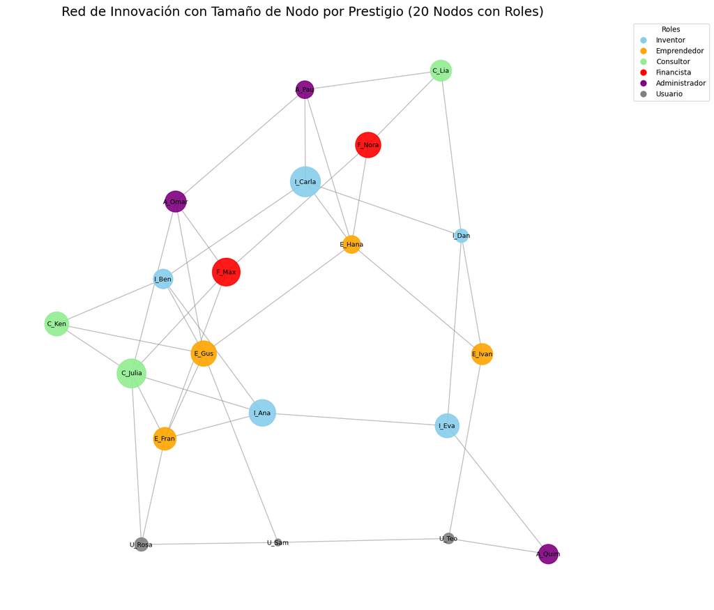

```python
import matplotlib.pyplot as plt
import numpy as np


### Asignar colores basados en ROLES
colorsForRoles = {
    'Inventor': 'skyblue',
    'Emprendedor': 'orange',
    'Consultor': 'lightgreen',
    'Financista': 'red',
    'Administrador': 'purple',
    'Usuario': 'gray'}
colors = [colorsForRoles[innovation_network.nodes[node]['role']] for node in innovation_network.nodes()]

### Asignar tamaño en basados a PRESTIGIO
# prestigio de todos los nodos
prestigio_values = [innovation_network.nodes[node]['prestigio'] for node in innovation_network.nodes()]

# tamaño entre 100 a 1800
min_prestigio = min(prestigio_values)
max_prestigio = max(prestigio_values)
newMax=1800
newMin=100
scaled_prestigio = [
    ((p - min_prestigio) / (max_prestigio - min_prestigio) * (newMax - newMin) + newMin)
    for p in prestigio_values]


### Configurar las etiquetas de los nodos (mostrar el nombre del nodo)
labels = {node: node for node in innovation_network.nodes()}

###  Generar el Gráfico
plt.figure(figsize=(14, 12)) # tamaño de la figura
pos = nx.spring_layout(innovation_network, seed=50) # seed para reproducibilidad

# Dibuja los nodos con el tamaño escalado por prestigio
nx.draw_networkx_nodes(innovation_network, pos, node_color=colors, node_size=scaled_prestigio, alpha=0.9)
nx.draw_networkx_edges(innovation_network, pos, edge_color='gray', alpha=0.6)
nx.draw_networkx_labels(innovation_network, pos, labels, font_size=9, font_color='black')

# Añadir leyenda de roles (para entender los colores)
legend_handles = []
for role, color in colorsForRoles.items():
    legend_handles.append(plt.Line2D([0], [0], marker='o', color='w', label=role,
                                     markerfacecolor=color, markersize=10))
plt.legend(handles=legend_handles, title="Roles", bbox_to_anchor=(1.05, 1), loc='upper left')

plt.title("Red de Innovación con Tamaño de Nodo por Prestigio (20 Nodos con Roles)", size=18)
plt.axis('off') # Ocultar los ejes
plt.tight_layout() # Ajusta el layout para que la leyenda no se solape
plt.show()
```

## Modelos de Red Básicos y sus Implicaciones para la Innovación

### 1. Modelo de Erdös-Rényi (E-R): Redes Aleatorias

El modelo E-R es el más simple de entender. Imagina un grupo de nodos y una probabilidad $p$ de que exista un enlace entre cualquier par de ellos. Cada conexión es independiente de las demás.

**Conceptos Básicos:**

- **Formación Aleatoria:** Los enlaces se forman de manera completamente aleatoria e independiente.
- **Grado Homogéneo:** La mayoría de los nodos tienen un número similar de conexiones (grado), lo que significa que no hay nodos "súper conectados" o "hubs" muy pronunciados.
- **Distancia Corta:** A medida que la red crece, la distancia promedio entre nodos tiende a ser corta.

**Ventajas Teóricas para la Innovación:**

- **Difusión Rápida a Corta Distancia:** Si la red es lo suficientemente densa, las ideas pueden viajar rápidamente entre cualquier par de nodos debido a las distancias cortas. Esto podría favorecer la **difusión global de innovaciones no complejas**.
- **Resiliencia a Fallos Dirigidos:** Como no hay hubs obvios, eliminar un nodo aleatorio tiene un impacto limitado en la conectividad general. Esto podría implicar que la red es **robusta frente a la pérdida de un actor específico**, ya que la conectividad no depende de unos pocos.

**Desventajas Teóricas para la Innovación:**

- **Falta de Estructura de Comunidad:** La aleatoriedad no favorece la formación de comunidades o clústeres densos, que son cruciales para el **intercambio de conocimiento tácito** y la **construcción de confianza**. La innovación compleja y el aprendizaje suelen requerir interacciones frecuentes y cercanas.
- **Ineficiencia en la Búsqueda:** Sin nodos centrales, encontrar información específica o el conocimiento adecuado puede ser menos eficiente, ya que no hay "expertos" o "gatekeepers" claros que faciliten el flujo.
- **Poca Resiliencia a Fallos Aleatorios Masivos:** Si se produce un fallo aleatorio a gran escala (muchos nodos se desconectan al azar), la red puede fragmentarse rápidamente.

### 2. Modelo de Barabási-Albert (BA): Redes de Escala Libre

El modelo BA introduce el concepto de "preferential attachment" (adjunción preferencial) o "los ricos se hacen más ricos". Los nuevos nodos prefieren conectarse a nodos que ya tienen muchas conexiones.

**Conceptos Básicos:**

- **Preferencia de Conexión:** Los nodos más conectados atraen más conexiones.
- **Distribución de Grado de Ley de Potencia:** Se forman unos pocos nodos con un número extremadamente alto de conexiones (hubs) y muchos nodos con pocas conexiones.
- **Redes con "Hubs":** La presencia de estos hubs es la característica distintiva.

**Ventajas Teóricas para la Innovación:**

- **Eficiencia de Difusión:** Los hubs actúan como **supercarreteras para el flujo de información y conocimiento**. Una idea innovadora en un hub puede propagarse rápidamente a una vasta porción de la red. Esto es ideal para la **difusión rápida y de amplio alcance**.
- **Búsqueda Eficiente:** Es más fácil encontrar información o el actor adecuado, ya que los hubs sirven como **puntos de acceso centralizados** para diversos dominios de conocimiento.
- **Robustez frente a Fallos Aleatorios:** Si un nodo aleatorio falla, es probable que no sea un hub, por lo que el impacto en la conectividad general es mínimo. La red es **altamente resiliente a fallos aleatorios**.

**Desventajas Teóricas para la Innovación:**

- **Vulnerabilidad a Fallos Dirigidos:** Si un hub es el que falla (o se convierte en un cuello de botella, por ejemplo, por sobrecarga), el **impacto es catastrófico** para la conectividad y el flujo de la red. En innovación, esto significa que la pérdida de un "super-inventor" o un "financista clave" puede detener el progreso en varias áreas.
- **Riesgo de Homogeneidad:** Si la información fluye predominantemente a través de los mismos hubs, podría llevar a una **menor diversidad de ideas** o a un pensamiento de grupo, limitando la innovación disruptiva que a menudo surge de la periferia.
- **Dependencia Excesiva:** La red depende demasiado de la salud y el rendimiento de unos pocos nodos clave.

### 3. Modelo de Watts-Strogatz (WS): Redes de Mundo Pequeño

El modelo WS busca un equilibrio entre el orden y el desorden. Combina la **alta agrupación** (similar a las redes regulares) con **caminos cortos** (similar a las redes aleatorias). Se construye a partir de una red regular con alta conectividad local, y luego se "recablean" aleatoriamente una pequeña fracción de enlaces.

**Conceptos Básicos:**

- **Alta Agrupación (Clustering):** Los nodos tienden a formar clústeres densos o comunidades (los "amigos de mis amigos son mis amigos").
- **Caminos Cortos:** A pesar de la alta agrupación, la distancia promedio entre nodos es sorprendentemente corta debido a unos pocos "atajos" aleatorios (los enlaces recableados).
- **Equilibrio Local-Global:** Captura la combinación de conectividad local fuerte y conectividad global eficiente.

**Ventajas Teóricas para la Innovación:**

- **Ideal para Conocimiento Tácito y Confianza:** La alta agrupación facilita la **interacción repetida y el desarrollo de confianza** dentro de las comunidades. Esto es crucial para el **intercambio de conocimiento tácito** y la colaboración en proyectos complejos de innovación.
- **Propagación Eficiente de la Novedad:** Los caminos cortos garantizan que, a pesar de la formación de grupos, las **nuevas ideas pueden difundirse rápidamente** a través de toda la red, saltando entre comunidades a través de los "atajos".
- **Robustez Equilibrada:** Ofrece un buen balance entre la robustez a fallos aleatorios (debido a la alta redundancia local) y la vulnerabilidad a ataques dirigidos, sin la dependencia extrema de los hubs del modelo BA.

**Desventajas Teóricas para la Innovación:**

- **Menos Eficiente que BA para Difusión Masiva:** Aunque los caminos son cortos, puede que no sea tan eficiente como una red de escala libre para la **difusión explosiva** desde un único punto, ya que carece de los hubs superconectados.
- **Identificación de "Puentes" Crítica:** La eficiencia depende en gran medida de esos pocos enlaces recableados (puentes). Identificar y mantener estos **"puentes" entre comunidades** es esencial; su pérdida puede afectar la difusión global.

[figure not shown]

### Conclusión para la Red de Innovación

Al analizar nuestra propia red de innovación, podemos ver a cuál de estas arquitecturas teóricas nos parecemos. Por ejemplo:

- Si nuestra red se parece más a un **E-R**, el flujo es homogéneo pero quizás carezca de la especialización o las comunidades necesarias.
- Si se asemeja a un **BA**, la innovación podría ser muy eficiente si se dirige a los hubs, pero vulnerable si esos hubs fallan.
- Si se alinea con un **WS**, la red probablemente tiene una **excelente capacidad para el desarrollo profundo de ideas (gracias al clustering)** y para su **difusión efectiva (gracias a los caminos cortos)**, lo que a menudo se considera una estructura muy ventajosa para la innovación.

Creemos una función para describir esta red:

```python
# Métricas
def analizar_red(G, nombre):
    """Retorna un diccionario con métricas clave, incluyendo el nodo más conectado."""
    largest_component_nodes = max(nx.connected_components(G), key=len)
    G_cgc = G.subgraph(largest_component_nodes).copy()

    # Cálculo del grado máximo y nodo correspondiente
    grados = dict(G_cgc.degree())
    grado_maximo = max(grados.values())
    nodo_maximo = next(nodo for nodo, grado in grados.items() if grado == grado_maximo)

    metricas = {
        'nombre': nombre,
        'nodos_total': len(G),
        'componentes': nx.number_connected_components(G),
        'nodos_gigante': len(G_cgc),
        'porcentaje_gigante': (len(G_cgc) / len(G)) * 100,  # Movido dentro del dict
        'grado_promedio_gigante': sum(grados.values()) / len(G_cgc),
        'grado_maximo': grado_maximo,  # Nuevo: grado del nodo más conectado
        'nodo_mas_conectado': nodo_maximo,  # Nuevo: ID del nodo
        'clustering_gigante': nx.average_clustering(G_cgc),
        'distancia_promedio_gigante': nx.average_shortest_path_length(G_cgc)

    }
    return metricas
```

```python
metricas_iniciales = analizar_red(innovation_network, "Mi Red")
metricas_iniciales
```

```
{'nombre': 'Mi Red',
 'nodos_total': 20,
 'componentes': 1,
 'nodos_gigante': 20,
 'porcentaje_gigante': 100.0,
 'grado_promedio_gigante': 3.8,
 'grado_maximo': 6,
 'nodo_mas_conectado': 'E_Gus',
 'clustering_gigante': 0.12833333333333333,
 'distancia_promedio_gigante': 2.278947368421053}
```

### **Análisis de Métricas para Redes de Innovación** 🚀

#### **1. `nombre`: "Mi Red"**

- **¿Qué es?** Identificador de la red.
- **Importancia**: Permite diferenciar entre múltiples redes (ej. "Red de Startups 2023" vs "Red de Investigación").

#### **2. `nodos_total`: 20**

- **¿Qué es?** Número total de actores en la red.
- **Importancia**:
  - Redes pequeñas (<50 nodos) son típicas en innovación local o equipos específicos.
  - Mide el "tamaño del ecosistema".

#### **3. `componentes`: 1**

- **¿Qué es?** Componentes conectados (subredes aisladas).
- **Importancia**:
  - **1 componente** = Todos están conectados (ideal para colaboración).
  - Si hubiera >1, habría grupos que no interactúan (problema para transferencia de conocimiento).

#### **4. `nodos_gigante`: 20**

- **¿Qué es?** Tamaño del componente principal (100% aquí).
- **Importancia**:
  - Confirma que **toda la red está conectada** (no hay nodos aislados).

#### **5. `porcentaje_gigante`: 100%**

- **¿Qué es?** % de nodos en el componente principal.
- **Importancia**:
  - **100% = Red totalmente conectada**.
  - Si fuera <90%, habría actores "desconectados" del ecosistema principal.

#### **6. `grado_promedio_gigante`: 3.8**

- **¿Qué es?** Promedio de conexiones por nodo.
- **Importancia**:
  - **3.8 conexiones/nodo** sugiere una red **bien conectada** (no densa, pero tampoco dispersa).
  - En innovación: Balance entre diversidad y gestión de relaciones.

#### **8. `clustering_gigante`: ~0.128**

- **¿Qué es?** Probabilidad de que dos conexiones de un nodo estén conectadas entre sí.
- **Importancia**:
  - **Bajo clustering (0.13)**: Pocos "triángulos" de colaboración.
  - Típico en redes donde:
    - Los nodos se conectan a un **hub central** (ej. consultores) pero no entre ellos.
    - La colaboración es **vertical** (no horizontal).

#### **9. `distancia_promedio_gigante`: ~2.28**

- **¿Qué es?** Pasos promedio para ir de un nodo a otro.
- **Importancia**:
  - **2.28 es bajo** (¡la información fluye rápido!).
  - En innovación: Favorece la **difusión de ideas** y **acceso a recursos**.
  - Comparación:
    - Redes aleatorias (ER): ~2.5-3.
    - Redes mundo pequeño (WS): ~2-2.5.

Nuestra red es:  
✅ **Bien conectada** (grado promedio 3.8, distancia corta).  
✅ **Dependiente de hubs** (E_Gus con grado 6 centraliza flujos).  
⚠️ **Poco clustering** (0.128): Sugiere que **los nodos no forman grupos densos** (ej. equipos estables de colaboración).

### **Comparación con Modelos Teóricos**

Basado en las métricas (`grado_promedio = 3.8`, `grado_maximo = 6`, `clustering = 0.128`, `distancia = 2.28`):

#### **2. Watts-Strogatz (Mundo Pequeño)** 🕸️

- **Similitudes**:
  - Distancia corta (2.28 vs ~2.3 en WS con *k=4*, *p=0.1*).
  - Clustering moderado (0.128 vs ~0.15 en WS con *p=0.1*).
- **Diferencias**:
  - **Grado máximo**: Tu red (6) vs WS (~4-5). *Tu "E_Gus" destaca más*.
  - **Distribución de grados**: WS espera homogeneidad; tu red tiene ligeros hubs.
- **Veredicto**:
  - **Cercana a WS**, pero con un nodo más centralizado. Podría ser WS con *p bajo* (poco "rewiring").

#### **3. Barabási-Albert (Red Libre de Escala)** 📊

- **Similitudes**:
  - Presencia de hubs ("E_Gus" con grado 6).
  - Distancia ultra-corta (2.28 vs ~2.1 en BA para *n=20*).
- **Diferencias**:
  - **Clustering**: Tu red (0.128) vs BA (~0.01). *Tu red tiene más agrupamiento*.
  - **Grado máximo**: BA esperaría ~8-12 conexiones para el hub (no 6).
- **Veredicto**:
  - **No es BA puro**. Los hubs no son suficientemente extremos y el clustering es alto.

# Roles y Comunidades

Las comunidades son conjuntos de nodos que interactuan mas entre sí que con el resto. Usemos el algoritmo de Louvain:

```python
innovaLouvain=nx.community.louvain_communities(innovation_network, seed=123)
innovaLouvain_attr={z:x for x,y  in enumerate(innovaLouvain) for z in y }
for node, community_id in innovaLouvain_attr.items():
    innovation_network.nodes[node]['community'] = community_id

# --- TABLA DE NODOS, ROLES Y COMUNIDADES ---

import pandas as pd

print("\n--- Tabla Detallada de Nodos, Roles y Comunidades Asignadas ---")

data_for_table = []
nodes_in_order = list(innovation_network.nodes()) # Asegura un orden consistente
for node_name in nodes_in_order:
    node_role = innovation_network.nodes[node_name].get('role', 'Desconocido')
    # Usamos 'community' en lugar de 'block' ahora
    node_community = innovation_network.nodes[node_name].get('community', 'No Asignado')
    data_for_table.append({
        'Nodo': node_name,
        'Rol Predefinido': node_role,
        'Comunidad Asignada': node_community
    })

communities_df = pd.DataFrame(data_for_table)
# Ordenar la tabla para agrupar las comunidades y luego los roles
communities_df = communities_df.sort_values(by=['Comunidad Asignada', 'Rol Predefinido']).reset_index(drop=True)
print(communities_df.to_string())

print("\n--- Resumen: Cantidad de Nodos por Comunidad y Rol ---")
# Generar una tabla pivot para ver la distribución de roles en cada comunidad
summary_community_table = communities_df.groupby(['Comunidad Asignada', 'Rol Predefinido']).size().unstack(fill_value=0)
print(summary_community_table.to_string())
```

```
--- Tabla Detallada de Nodos, Roles y Comunidades Asignadas ---
       Nodo Rol Predefinido  Comunidad Asignada
0     C_Ken       Consultor                   0
1     E_Gus     Emprendedor                   0
2     I_Ben        Inventor                   0
3     A_Pau   Administrador                   1
4     C_Lia       Consultor                   1
5    E_Hana     Emprendedor                   1
6    E_Ivan     Emprendedor                   1
7    F_Nora      Financista                   1
8   I_Carla        Inventor                   1
9     I_Dan        Inventor                   1
10   A_Omar   Administrador                   2
11  C_Julia       Consultor                   2
12   E_Fran     Emprendedor                   2
13    F_Max      Financista                   2
14    I_Ana        Inventor                   2
15   U_Rosa         Usuario                   2
16   A_Quim   Administrador                   3
17    I_Eva        Inventor                   3
18    U_Sam         Usuario                   3
19    U_Teo         Usuario                   3

--- Resumen: Cantidad de Nodos por Comunidad y Rol ---
Rol Predefinido     Administrador  Consultor  Emprendedor  Financista  Inventor  Usuario
Comunidad Asignada
0                               0          1            1           0         1        0
1                               1          1            2           1         2        0
2                               1          1            1           1         1        1
3                               1          0            0           0         1        2
```

### **Cómo el Rol vs. Comunidad Te Ayuda a Entender tu Red de Innovación**

#### **1. Identificar Patrones Ocultos**

- **Ejemplo**:
  - Si todos los **financistas** (`F_*`) están en la **misma comunidad**, su capital puede estar concentrado en ciertos proyectos.
  - Si los **usuarios** (`U_*`) están **separados de los inventores**, hay riesgo de desconexión entre necesidades y soluciones.

#### **2. Optimizar Flujos de Innovación**

- **Problema común**:
  - Si los **consultores** (`C_*`) son los únicos que conectan comunidades, son cuellos de botella.

#### **3. Detectar Desequilibrios**

- **Ejemplo**:
  - Si una comunidad tiene **solo inventores** y otra **solo emprendedores**, hay riesgo de que las ideas no se ejecuten.

#### **4. Mejorar Intervenciones**

- **Acciones basadas en roles vs. comunidades**:
  - **Si quieres difundir tecnología**: Como `E_Gus` (grado 6) me puede servir más?
  - **Si quieres integrar usuarios**: Añado un consultor o inventor en otra comunidad?

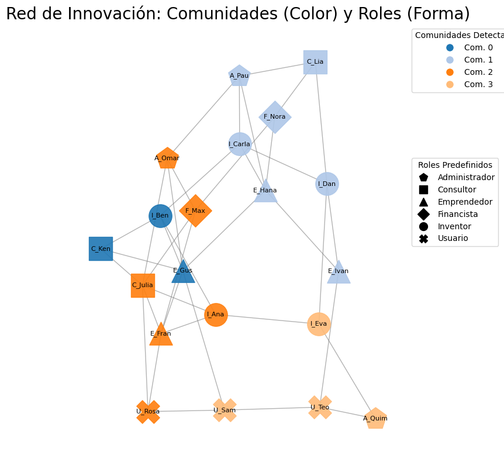

```python
plt.figure(figsize=(8, 8))
pos = nx.spring_layout(innovation_network, seed=50) # Mantiene la posición consistente para comparación

community_colors_map = plt.colormaps.get_cmap('tab20')

# Formas para cada ROL (reutilizamos las mismas formas)
role_shapes_map = {
    'Inventor': 'o',          # Círculo
    'Emprendedor': '^',       # Triángulo
    'Consultor': 's',         # Cuadrado
    'Financista': 'D',        # Diamante
    'Administrador': 'p',     # Pentágono
    'Usuario': 'X'            # Cruz grande
}
# Obtener todos los roles presentes en tu red para la leyenda
all_roles = sorted(list(set(nx.get_node_attributes(innovation_network, 'role').values())))

# Dibujar cada nodo individualmente para aplicar color (comunidad) y forma (rol)
for node in innovation_network.nodes():
    community_id = innovation_network.nodes[node]['community']
    role = innovation_network.nodes[node].get('role', 'o') # 'o' por defecto si el rol no existe/mapea

    nx.draw_networkx_nodes(
        innovation_network, pos,
        nodelist=[node],
        node_color=[community_colors_map(community_id % 20)], # Usamos % 20 para rotar colores si hay más de 20 comunidades
        node_shape=role_shapes_map.get(role, 'o'), # Usa la forma del rol, 'o' si no está en el mapa
        node_size=800,
        alpha=0.9
    )

nx.draw_networkx_edges(innovation_network, pos, edge_color='gray', alpha=0.6)
nx.draw_networkx_labels(innovation_network, pos, {node: node for node in innovation_network.nodes()},
                       font_size=8, font_color='black')

plt.title("Red de Innovación: Comunidades (Color) y Roles (Forma)", size=20)

# Crear leyendas para Comunidades y Roles
legend_handles_communities = [
    plt.Line2D([0], [0], marker='o', color='w', label=f'Com. {comm_id}',
               markerfacecolor=community_colors_map(comm_id % 20), markersize=10)
    for comm_id in sorted(list(set(innovaLouvain_attr.values())))
]

legend_handles_roles = [
    plt.Line2D([0], [0], marker=role_shapes_map.get(role_name, 'o'), color='w', label=role_name,
               markerfacecolor='black', markeredgecolor='black', markersize=10)
    for role_name in all_roles
]

# Añadir ambas leyendas
first_legend = plt.legend(handles=legend_handles_communities, title="Comunidades Detectadas",
                          loc='upper left', bbox_to_anchor=(1.01, 1))

ax = plt.gca()
ax.add_artist(first_legend)

plt.legend(handles=legend_handles_roles, title="Roles Predefinidos",
           loc='upper left', bbox_to_anchor=(1.01, 0.7)) # Ajusta 0.7 si se solapa

plt.axis('off')
plt.tight_layout(rect=[0, 0, 0.95, 1])
plt.show()
```

# Es nuestrs red 'resiliente'?

La manera practica de saberlo, es ver cuanto nodos se necesita retirar al azar para ver como cae el tamaño del componente principal:

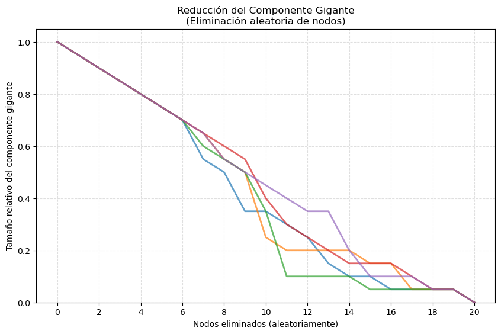

```python
import random

def simular_componente_gigante(G, n_simulaciones=5):
    plt.figure(figsize=(10, 6))

    for _ in range(n_simulaciones):
        G_copy = G.copy()
        nodos = list(G_copy.nodes())
        random.shuffle(nodos)

        tamano_original = len(G_copy)
        tamanos = []

        for i in range(len(nodos)+1):
            if i > 0:
                G_copy.remove_node(nodos[i-1])

            if G_copy.number_of_nodes() == 0:
                tamanos.append(0)
            else:
                componente_gigante = max(nx.connected_components(G_copy), key=len)
                tamanos.append(len(componente_gigante)/tamano_original)

        plt.plot(range(len(nodos)+1), tamanos, alpha=0.7, linewidth=2)

    # Configuración del eje X con enteros
    plt.xticks(range(0, len(G.nodes())+1, max(1, len(G.nodes())//10)))  # Muestra ~10 marcas en el eje X
    plt.xlabel('Nodos eliminados (aleatoriamente)')
    plt.ylabel('Tamaño relativo del componente gigante')
    plt.title('Reducción del Componente Gigante\n(Eliminación aleatoria de nodos)')
    plt.grid(True, linestyle='--', alpha=0.4)
    plt.ylim(0, 1.05)
    plt.show()


# Ejecutar simulación

simular_componente_gigante(innovation_network)
```

```python
import networkx as nx
import pandas as pd

def analizar_redundancia(G):
    # Identificar enlaces críticos
    puentes = list(nx.bridges(G))
    edge_betweenness = nx.edge_betweenness_centrality(G)

    # Obtener los 5 enlaces con mayor betweenness
    top_betweenness = sorted(edge_betweenness.items(), key=lambda x: -x[1])[:5]

    # Combinar puentes y enlaces con alta betweenness
    enlaces_criticos = list(set(puentes + [edge for edge, _ in top_betweenness]))

    # Generar sugerencias de redundancia
    sugerencias = []
    for u, v in enlaces_criticos:
        # Obtener roles de los nodos conectados
        rol_u = G.nodes[u]['role']
        rol_v = G.nodes[v]['role']

        # Generar sugerencia basada en los roles
        if rol_u == 'Consultor' or rol_v == 'Consultor':
            sugerencia = f"Añadir conexión alternativa a otro {rol_v if rol_u == 'Consultor' else rol_u}"
        elif rol_u == 'Financista' or rol_v == 'Financista':
            sugerencia = "Establecer conexión secundaria con administrador"
        else:
            sugerencia = "Crear enlace paralelo o conectar a nodo intermediario"

        sugerencias.append({
            'Enlace': f"{u} ↔ {v}",
            'Tipo': "Puente" if (u,v) in puentes else "Alto tráfico",
            'Betweenness': round(edge_betweenness[(u,v)], 4),
            'Rol Origen': rol_u,
            'Rol Destino': rol_v,
            'Sugerencia': sugerencia
        })

    # Crear DataFrame con los resultados
    df = pd.DataFrame(sugerencias)
    return df.sort_values('Betweenness', ascending=False)

# Ejecutar análisis
tabla_redundancia = analizar_redundancia(innovation_network)

# Mostrar tabla
print("\nEnlaces críticos y sugerencias de redundancia:")
display(tabla_redundancia)
```

```
Enlaces críticos y sugerencias de redundancia:
```

|  | Enlace | Tipo | Betweenness | Rol Origen | Rol Destino | Sugerencia |
| --- | --- | --- | --- | --- | --- | --- |
| 2 | I_Ana ↔ I_Eva | Alto tráfico | 0.1157 | Inventor | Inventor | Crear enlace paralelo o conectar a nodo interm... |
| 3 | E_Gus ↔ E_Hana | Alto tráfico | 0.1038 | Emprendedor | Emprendedor | Crear enlace paralelo o conectar a nodo interm... |
| 0 | E_Gus ↔ U_Sam | Alto tráfico | 0.0970 | Emprendedor | Usuario | Crear enlace paralelo o conectar a nodo interm... |
| 4 | U_Sam ↔ U_Teo | Alto tráfico | 0.0914 | Usuario | Usuario | Crear enlace paralelo o conectar a nodo interm... |
| 1 | I_Dan ↔ I_Eva | Alto tráfico | 0.0893 | Inventor | Inventor | Crear enlace paralelo o conectar a nodo interm... |